# 05+06_assignment_chen

Evelyn Chen

10/12/2019

###Loading libraries and els.RData

### 1 - Choose a dependent variable and plot that dependent variable as a function of of a continuous independent variable

dependent variable: math score ‘bynels2m’ independent variable: reading score ‘bynels2r’

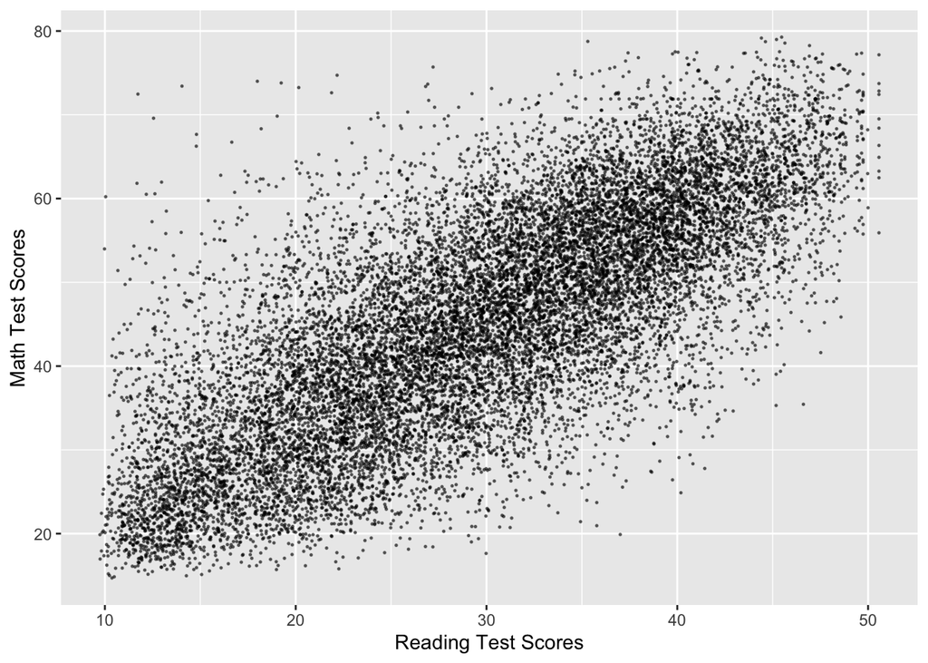

```r
g1<-ggplot(data=els,
           aes(x=bynels2r,y=bynels2m)
           )

g1<-g1+geom_point(alpha=.5,size=.25) # Add points at x and y
g1<-g1+ylab("Math Test Scores")+xlab("Reading Test Scores")
g1
```

The scatterplot suggests that as reading test scores increase, math test scores also tend to increase. There is a positive relationship between the independent and dependent variables.

### 2 - Adjust the scale of either the dependent variable or independent variable.

The NELS-equated estimated reading and math test scores (1992) scale range from 0-54 and 0-81, respectively. It makes sense to adjust the scale of either the independent and dependent variable.

To determine the average math score, at every percentile level of reading score ‘bynels2r’, I will use the mutate command to create a new variable. The use of ‘round’ will help to get whole number percentiles, elimindating the possibility of having decimals. This will help tidy up the appearance of our scatterplot.

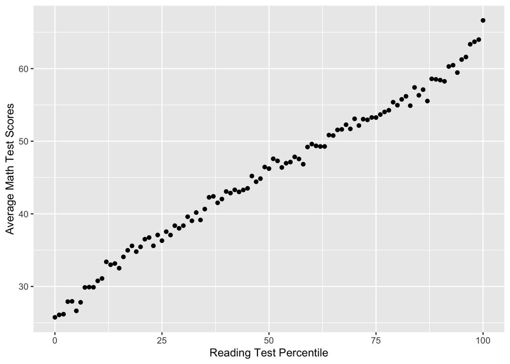

```r
els_sum<-els%>%
  mutate(read_rank=percent_rank(bynels2r)*100)%>%
  mutate(read_rank_r=round(read_rank))%>%
  group_by(read_rank_r)%>%
  summarize(test_mean=mean(bynels2m,na.omit=TRUE))

g2<-ggplot(els_sum,aes(x=read_rank_r,y=test_mean))

g2<-g2+geom_point()

g2<-g2+ylab("Average Math Test Scores")+xlab("Reading Test Percentile")

g2
```

### 3 - Add a line of best fit to your graph.

To above scatter plot indicates a fairly linear relationship between the percentile rank of reading scores (‘read_rank’) and the average math score (‘test_mean’) so it appears appropriate to eadd a linear regression line. To do this, I will use the ‘geom_smooth(method=“lm”)’ command.

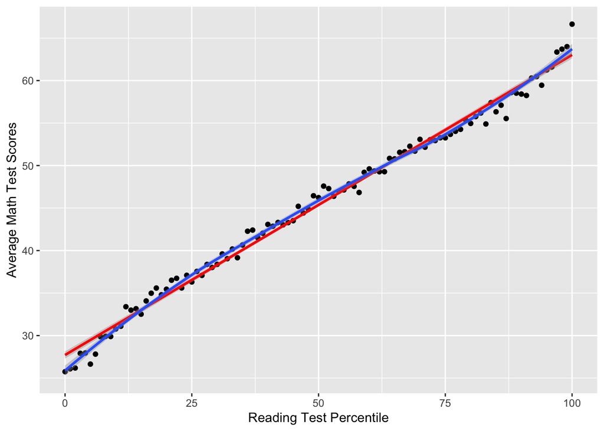

```r
#add a linear regression line
g2<-g2+geom_smooth(method="lm",colour="red")
#add a smoothed, loess line
g2<-g2+stat_smooth()
g2
```

### 4 - Clean up the labeling and description of the graphic so that it could be presented to a broader audience.

The graphic looks pretty clean, but I did add a descriptive title on the graph to further clarify what the content of the scatter plot demonstrates.

```r
g2<-print(g2+ggtitle("Average Math Scores Based on Reading Test Percentile Scores"))
```

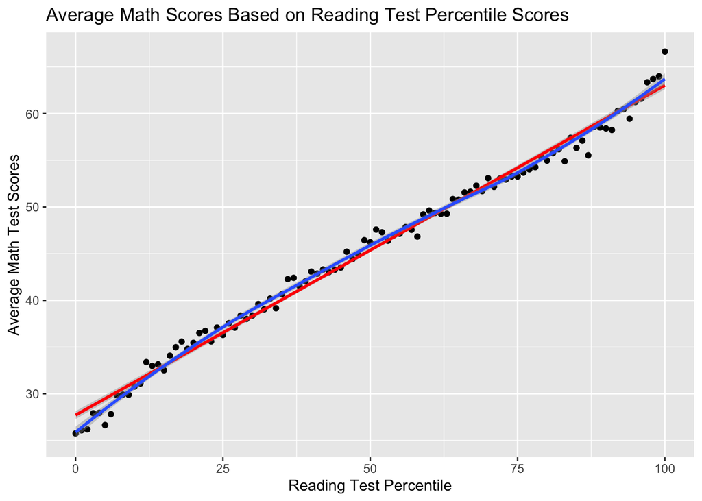

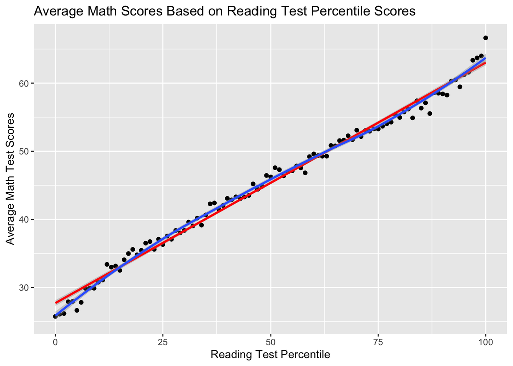

```r
g2
```

### 5 - Include a few sentences describing what the graphic above shows.

The scatterplot shows a positive relationship between reading test percentile rank and average math test scores. If a student has a higher percentile rank on the reading test, then they tend to also have a higher math score.

Both the loess and lm estimates show this positive relationship. The linear regression line is colored red, and the loess line is colored blue. Although the two lines appear similar, the blue loess line is a non-parametric approach that presents a smooth trend line. The loess line is a common method used to smoothen out a trend line if the data appears to be quite volatile. Given our dataset, the linear regression line is a better model. It has more predictive ability, and subsequent regression models can be interpreted for statistical significance.

### 6 - Create a regression that predicts reading scores as a function of SES plus one other covariate, using the training data.

Loading the training data

```r
load("els_train.RData")
```

I will first create a simple bivariate regression model that predicts reading scores as a function of SES. dependent variable = ‘bynels2r’ independent variable = ‘byses1’

To do this, I will use the ’lm(outcome~predictor,data=filename) command.

```r
#Model 1: simple bivariate regression
mod1<-lm(bynels2r~byses1,data=els_train)
summary(mod1)
```

```
##
## Call:
## lm(formula = bynels2r ~ byses1, data = els_train)
##
## Residuals:
##      Min       1Q   Median       3Q      Max
## -25.4572  -6.1499   0.2996   6.4041  24.3580
##
## Coefficients:
##             Estimate Std. Error t value Pr(>|t|)
## (Intercept) 29.39203    0.09808  299.68   <2e-16 ***
## byses1       5.51700    0.13176   41.87   <2e-16 ***
## ---
## Signif. codes:  0 '***' 0.001 '**' 0.01 '*' 0.05 '.' 0.1 ' ' 1
##
## Residual standard error: 8.562 on 7640 degrees of freedom
##   (502 observations deleted due to missingness)
## Multiple R-squared:  0.1867, Adjusted R-squared:  0.1866
## F-statistic:  1753 on 1 and 7640 DF,  p-value: < 2.2e-16
```

The simple regression model indicates that there is a relationship between socioeconomic status and reading test scores, because the coefficient of 5.52 is statistically significant. For every unit increase on the socioeconomic scale, there is a predicted 5.52 increase in reading score.

[figure not shown]

```r
g3<-ggplot(els_train, aes(x=byses1,y=bynels2r))+ #specify data and x and y
           geom_point(shape=1)+ #specify points
           geom_smooth(method=lm) #ask for lm line
g3<-g3+ylab("Socioeconomic Status")+xlab("Reading Test Score")
g3
```

Let’s add in a second variable: the parent’s level of education.

```r
##adding in parental education as an additional predictor, in addition to SES
mod2<-lm(bynels2r~as.factor(bypared)+
           byses1,
          data=els_train)

summary(mod2)
```

```
##
## Call:
## lm(formula = bynels2r ~ as.factor(bypared) + byses1, data = els_train)
##
## Residuals:
##      Min       1Q   Median       3Q      Max
## -24.5191  -6.1067   0.3254   6.3707  25.0240
##
## Coefficients:
##                     Estimate Std. Error t value Pr(>|t|)
## (Intercept)         30.13133    0.47880  62.932  < 2e-16 ***
## as.factor(bypared)2  0.03628    0.46850   0.077 0.938268
## as.factor(bypared)3 -1.10618    0.54134  -2.043 0.041047 *
## as.factor(bypared)4 -0.14097    0.55830  -0.252 0.800666
## as.factor(bypared)5 -0.56048    0.55638  -1.007 0.313784
## as.factor(bypared)6 -1.04515    0.57759  -1.809 0.070415 .
## as.factor(bypared)7 -1.30913    0.67367  -1.943 0.052019 .
## as.factor(bypared)8 -2.70343    0.76637  -3.528 0.000422 ***
## byses1               6.21024    0.23311  26.641  < 2e-16 ***
## ---
## Signif. codes:  0 '***' 0.001 '**' 0.01 '*' 0.05 '.' 0.1 ' ' 1
##
## Residual standard error: 8.551 on 7633 degrees of freedom
##   (502 observations deleted due to missingness)
## Multiple R-squared:  0.1895, Adjusted R-squared:  0.1887
## F-statistic: 223.1 on 8 and 7633 DF,  p-value: < 2.2e-16
```

```r
#Summary of the simple bivariate linear regression model
summary(mod1)
```

```
##
## Call:
## lm(formula = bynels2r ~ byses1, data = els_train)
##
## Residuals:
##      Min       1Q   Median       3Q      Max
## -25.4572  -6.1499   0.2996   6.4041  24.3580
##
## Coefficients:
##             Estimate Std. Error t value Pr(>|t|)
## (Intercept) 29.39203    0.09808  299.68   <2e-16 ***
## byses1       5.51700    0.13176   41.87   <2e-16 ***
## ---
## Signif. codes:  0 '***' 0.001 '**' 0.01 '*' 0.05 '.' 0.1 ' ' 1
##
## Residual standard error: 8.562 on 7640 degrees of freedom
##   (502 observations deleted due to missingness)
## Multiple R-squared:  0.1867, Adjusted R-squared:  0.1866
## F-statistic:  1753 on 1 and 7640 DF,  p-value: < 2.2e-16
```

```r
#Summary of the two-predictor regression model
summary(mod2)
```

```
##
## Call:
## lm(formula = bynels2r ~ as.factor(bypared) + byses1, data = els_train)
##
## Residuals:
##      Min       1Q   Median       3Q      Max
## -24.5191  -6.1067   0.3254   6.3707  25.0240
##
## Coefficients:
##                     Estimate Std. Error t value Pr(>|t|)
## (Intercept)         30.13133    0.47880  62.932  < 2e-16 ***
## as.factor(bypared)2  0.03628    0.46850   0.077 0.938268
## as.factor(bypared)3 -1.10618    0.54134  -2.043 0.041047 *
## as.factor(bypared)4 -0.14097    0.55830  -0.252 0.800666
## as.factor(bypared)5 -0.56048    0.55638  -1.007 0.313784
## as.factor(bypared)6 -1.04515    0.57759  -1.809 0.070415 .
## as.factor(bypared)7 -1.30913    0.67367  -1.943 0.052019 .
## as.factor(bypared)8 -2.70343    0.76637  -3.528 0.000422 ***
## byses1               6.21024    0.23311  26.641  < 2e-16 ***
## ---
## Signif. codes:  0 '***' 0.001 '**' 0.01 '*' 0.05 '.' 0.1 ' ' 1
##
## Residual standard error: 8.551 on 7633 degrees of freedom
##   (502 observations deleted due to missingness)
## Multiple R-squared:  0.1895, Adjusted R-squared:  0.1887
## F-statistic: 223.1 on 8 and 7633 DF,  p-value: < 2.2e-16
```